[figure not shown]

# Titanic - Machine Learning from Disaster

## Problem Definition

In a statement,

> Knowing from a training set of samples listing passengers who survived or did not survive the Titanic disaster, can our model determine based on a given test dataset not containing the survival information, if these passengers in the test dataset survived or not.

## Importing the libraries

```python
# Import Dependencies
%matplotlib inline

# Start Python Imports
import math, time, random, datetime

# Data Manipulation
import numpy as np
import pandas as pd

# Visualization
import matplotlib.pyplot as plt
import missingno
import seaborn as sns
plt.style.use('seaborn-whitegrid')

# # Preprocessing
from sklearn.metrics import accuracy_score, classification_report
from sklearn.tree import DecisionTreeClassifier
from sklearn.neighbors import KNeighborsClassifier
from sklearn.naive_bayes import GaussianNB

import warnings
warnings.filterwarnings('ignore')
```

## Acquire data

```python
train_df = pd.read_csv('data/train.csv')
```

```python
train_df.head()  # head = view first 5 lines
```

|  | PassengerId | Survived | Pclass | Name | Sex | Age | SibSp | Parch | Ticket | Fare | Cabin | Embarked |
| --- | --- | --- | --- | --- | --- | --- | --- | --- | --- | --- | --- | --- |
| 0 | 1 | 0 | 3 | Braund, Mr. Owen Harris | male | 22.0 | 1 | 0 | A/5 21171 | 7.2500 | NaN | S |
| 1 | 2 | 1 | 1 | Cumings, Mrs. John Bradley (Florence Briggs Th... | female | 38.0 | 1 | 0 | PC 17599 | 71.2833 | C85 | C |
| 2 | 3 | 1 | 3 | Heikkinen, Miss. Laina | female | 26.0 | 0 | 0 | STON/O2. 3101282 | 7.9250 | NaN | S |
| 3 | 4 | 1 | 1 | Futrelle, Mrs. Jacques Heath (Lily May Peel) | female | 35.0 | 1 | 0 | 113803 | 53.1000 | C123 | S |
| 4 | 5 | 0 | 3 | Allen, Mr. William Henry | male | 35.0 | 0 | 0 | 373450 | 8.0500 | NaN | S |

## 1. Exploratory Data Analysis (EDA)

`Survival:` 0 = No, 1 = Yes

`pclass (Ticket class):` (1 = 1st), (2 = 2nd), (3 = 3rd)

`sex:` Sex

`Age:` Age in years

`sibsp:` number of siblings/spouses aboard the Titanic

`parch:` number of parents/children aboard the Titanic

`ticket:` Ticket number

`fare:` Passenger fare

`cabin:` Cabin number

`embarked:` Port of Embarkation: (C = Cherbourg), (Q = Queenstown), (S = Southampton)

```python
train_df.describe()
```

|  | PassengerId | Survived | Pclass | Age | SibSp | Parch | Fare |
| --- | --- | --- | --- | --- | --- | --- | --- |
| count | 891.000000 | 891.000000 | 891.000000 | 714.000000 | 891.000000 | 891.000000 | 891.000000 |
| mean | 446.000000 | 0.383838 | 2.308642 | 29.699118 | 0.523008 | 0.381594 | 32.204208 |
| std | 257.353842 | 0.486592 | 0.836071 | 14.526497 | 1.102743 | 0.806057 | 49.693429 |
| min | 1.000000 | 0.000000 | 1.000000 | 0.420000 | 0.000000 | 0.000000 | 0.000000 |
| 25% | 223.500000 | 0.000000 | 2.000000 | 20.125000 | 0.000000 | 0.000000 | 7.910400 |
| 50% | 446.000000 | 0.000000 | 3.000000 | 28.000000 | 0.000000 | 0.000000 | 14.454200 |
| 75% | 668.500000 | 1.000000 | 3.000000 | 38.000000 | 1.000000 | 0.000000 | 31.000000 |
| max | 891.000000 | 1.000000 | 3.000000 | 80.000000 | 8.000000 | 6.000000 | 512.329200 |

## 1.1 What datatypes are in the dataframe?

**Which features are categorical?**

- Categorical: Survived, Sex, and Embarked. Ordinal: Pclass.

**Which features are numerical?**

- Continous: Age, Fare. Discrete: SibSp, Parch.

```python
train_df.dtypes
```

```
PassengerId      int64
Survived         int64
Pclass           int64
Name            object
Sex             object
Age            float64
SibSp            int64
Parch            int64
Ticket          object
Fare           float64
Cabin           object
Embarked        object
dtype: object
```

```python
train_df.info()
```

```
<class 'pandas.core.frame.DataFrame'>
RangeIndex: 891 entries, 0 to 890
Data columns (total 12 columns):
 #   Column       Non-Null Count  Dtype
---  ------       --------------  -----
 0   PassengerId  891 non-null    int64
 1   Survived     891 non-null    int64
 2   Pclass       891 non-null    int64
 3   Name         891 non-null    object
 4   Sex          891 non-null    object
 5   Age          714 non-null    float64
 6   SibSp        891 non-null    int64
 7   Parch        891 non-null    int64
 8   Ticket       891 non-null    object
 9   Fare         891 non-null    float64
 10  Cabin        204 non-null    object
 11  Embarked     889 non-null    object
dtypes: float64(2), int64(5), object(5)
memory usage: 83.7+ KB
```

## 1.2 What missing values are there?

Where are the holes in our data?

These are rows which are missing a value or have NaN instead of something like the rest of the column.

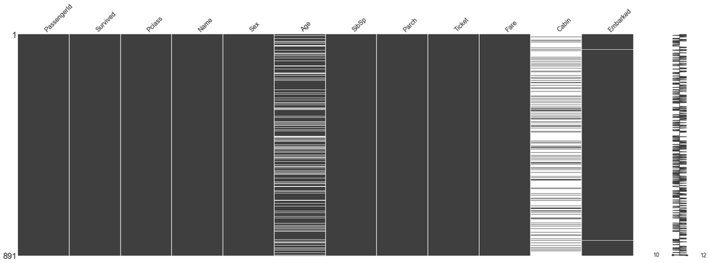

```python
# Plot graphic of missing values
missingno.matrix(train_df, figsize = (30,10))
```

```python
# Alternatively, you can see the number of missing values like this
train_df.isnull().sum()
```

```
PassengerId      0
Survived         0
Pclass           0
Name             0
Sex              0
Age            177
SibSp            0
Parch            0
Ticket           0
Fare             0
Cabin          687
Embarked         2
dtype: int64
```

```python
df = pd.DataFrame()
```

## 1.3 Explore each of these features individually

```python
train_df.head()
```

|  | PassengerId | Survived | Pclass | Name | Sex | Age | SibSp | Parch | Ticket | Fare | Cabin | Embarked |
| --- | --- | --- | --- | --- | --- | --- | --- | --- | --- | --- | --- | --- |
| 0 | 1 | 0 | 3 | Braund, Mr. Owen Harris | male | 22.0 | 1 | 0 | A/5 21171 | 7.2500 | NaN | S |
| 1 | 2 | 1 | 1 | Cumings, Mrs. John Bradley (Florence Briggs Th... | female | 38.0 | 1 | 0 | PC 17599 | 71.2833 | C85 | C |
| 2 | 3 | 1 | 3 | Heikkinen, Miss. Laina | female | 26.0 | 0 | 0 | STON/O2. 3101282 | 7.9250 | NaN | S |
| 3 | 4 | 1 | 1 | Futrelle, Mrs. Jacques Heath (Lily May Peel) | female | 35.0 | 1 | 0 | 113803 | 53.1000 | C123 | S |
| 4 | 5 | 0 | 3 | Allen, Mr. William Henry | male | 35.0 | 0 | 0 | 373450 | 8.0500 | NaN | S |

## 1.3.1 Target Feature: Survived

Description: Whether the passenger survived or not.

Key: `0 = did not survive` , `1 = survived`

```
0 = did not survive , 1 = survived
0    549
1    342
Name: Survived, dtype: int64
```

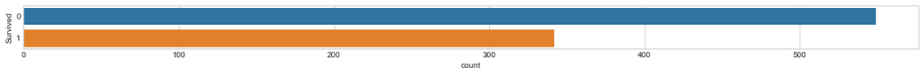

```python
# How many people survived?
fig = plt.figure(figsize=(20,1))
sns.countplot(y='Survived', data=train_df);
print("0 = did not survive , 1 = survived")
print(train_df.Survived.value_counts())
```

**Let's add this to our subset dataframes**

```python
df['Survived'] = train_df['Survived']
df.head()
```

|  | Survived |
| --- | --- |
| 0 | 0 |
| 1 | 1 |
| 2 | 1 |
| 3 | 1 |
| 4 | 0 |

## 1.3.2 Feature: Pclass

Description: The ticket class of the passenger.

Key: `1 = 1st`, `2 = 2nd`, `3 = 3rd`

```python
train_df['Pclass']
```

```
0      3
1      1
2      3
3      1
4      3
      ..
886    2
887    1
888    3
889    1
890    3
Name: Pclass, Length: 891, dtype: int64
```

### plot the distribution

if there are values which are completely outside of the distribution, we may not want to include them in our model.

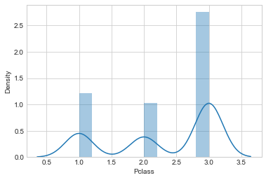

```python
sns.distplot(train_df.Pclass)
```

We can see with this feature, the values are numerical (1, 2 and 3) but they are categories.

**How many missing variables does Pclass have?**

```python
train_df.Pclass.isnull().sum()
```

```
0
```

Since there are no missing values in Pclass, let's add it to our sub dataframes.

```python
df['Pclass'] = train_df['Pclass']
df.head()
```

|  | Survived | Pclass |
| --- | --- | --- |
| 0 | 0 | 3 |
| 1 | 1 | 1 |
| 2 | 1 | 3 |
| 3 | 1 | 1 |
| 4 | 0 | 3 |

## 1.3.3 Feature: Name

Description: The name of the passenger.

**How many different names are there?**

```python
train_df.Name.value_counts()
```

```
Fortune, Miss. Mabel Helen                1
Turpin, Mr. William John Robert           1
Newsom, Miss. Helen Monypeny              1
Jensen, Mr. Hans Peder                    1
Kirkland, Rev. Charles Leonard            1
                                         ..
Pasic, Mr. Jakob                          1
Lennon, Mr. Denis                         1
Panula, Mrs. Juha (Maria Emilia Ojala)    1
Pears, Mrs. Thomas (Edith Wearne)         1
Petranec, Miss. Matilda                   1
Name: Name, Length: 891, dtype: int64
```

Every row has a unique name. This is equivalent to the passenger ID. But name could be used differently.

**Note:** Because of so many different names and to keep this EDA fast, we won't move forward using the name variable.

### 1.3.4 Feature: Sex

Description: The sex of the passenger (`male` or `female`).

```python
train_df.Sex.head()
```

```
0      male
1    female
2    female
3    female
4      male
Name: Sex, dtype: object
```

**Let's view the distribution of Sex**

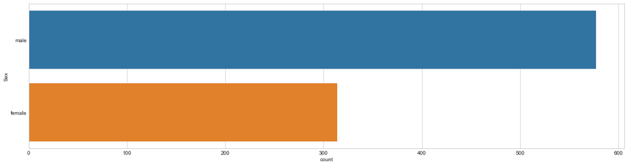

```python
plt.figure(figsize=(20, 5))
sns.countplot(y="Sex", data=train_df);
```

**Are there any missing values in the Sex column?**

```python
train_df.Sex.isnull().sum()
```

```
0
```

Since this is already binary variable (male or female), let's add it straight to our subset dataframes.

```python
# add Sex to the subset dataframes
df['Sex'] = train_df['Sex']
df['Sex'] = np.where(df['Sex'] == 'female', 1, 0) # change sex to 0 for male and 1 for female
df.head()
```

|  | Survived | Pclass | Sex |
| --- | --- | --- | --- |
| 0 | 0 | 3 | 0 |
| 1 | 1 | 1 | 1 |
| 2 | 1 | 3 | 1 |
| 3 | 1 | 1 | 1 |
| 4 | 0 | 3 | 0 |

**How does the Sex variable look compared to Survival?**

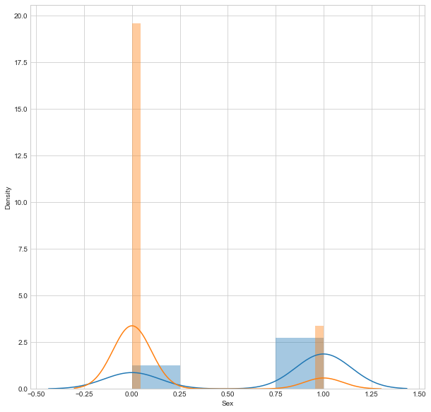

```python
fig = plt.figure(figsize=(10, 10))
sns.distplot(df.loc[df['Survived'] == 1]['Sex'], kde_kws={'label': 'Survived'});
sns.distplot(df.loc[df['Survived'] == 0]['Sex'], kde_kws={'label': 'Did not survive'});
```

Not many people survived. **But of those who did, more were female**.

### 1.3.5 Feature: Age

Description: The age of the passenger.

```python
train_df.Age.head()
```

```
0    22.0
1    38.0
2    26.0
3    35.0
4    35.0
Name: Age, dtype: float64
```

**How many missing values does age have?**

```python
train_df.Age.isnull().sum()
```

```
177
```

```python
train_df.Age.head(6)
```

```
0    22.0
1    38.0
2    26.0
3    35.0
4    35.0
5     NaN
Name: Age, dtype: float64
```

```python
train_df['Age'] = train_df['Age'].fillna((train_df['Age'].mean()))
```

```python
# add Age to the subset dataframes
df['Age'] = train_df['Age']
df.head(6)
```

|  | Survived | Pclass | Sex | Age |
| --- | --- | --- | --- | --- |
| 0 | 0 | 3 | 0 | 22.000000 |
| 1 | 1 | 1 | 1 | 38.000000 |
| 2 | 1 | 3 | 1 | 26.000000 |
| 3 | 1 | 1 | 1 | 35.000000 |
| 4 | 0 | 3 | 0 | 35.000000 |
| 5 | 0 | 3 | 0 | 29.699118 |

#### Function to create count and distribution visualisations

```python
def plot_count_dist(data, label_column, target_column, figsize=(20, 5)):
    """
    Function to plot counts and distributions of a label variable and
    target variable side by side.
    ::param_data:: = target dataframe
    ::param_label_column:: = binary labelled column
    ::param_target_column:: = column you want to view counts and distributions
    ::param_figsize:: = size of figure (width, height)
    """
    fig = plt.figure(figsize=figsize)
    plt.subplot(1, 2, 1)
    sns.countplot(y=target_column, data=data);
    plt.subplot(1, 2, 2)
    sns.distplot(data.loc[data[label_column] == 1][target_column],
                 kde_kws={"label": "Survived"});
    sns.distplot(data.loc[data[label_column] == 0][target_column],
                 kde_kws={"label": "Did not survive"});
```

## 1.3.6 Feature: SibSp

Description: The number of siblings/spouses the passenger has aboard the Titanic.

**How many missing values does SibSp have?**

```python
train_df.SibSp.isnull().sum()
```

```
0
```

**What values are there?**

```python
train_df.SibSp.value_counts()
```

```
0    608
1    209
2     28
4     18
3     16
8      7
5      5
Name: SibSp, dtype: int64
```

```python
# Add SibSp to subset dataframes
df['SibSp'] = train_df['SibSp']
df.head()
```

|  | Survived | Pclass | Sex | Age | SibSp |
| --- | --- | --- | --- | --- | --- |
| 0 | 0 | 3 | 0 | 22.0 | 1 |
| 1 | 1 | 1 | 1 | 38.0 | 1 |
| 2 | 1 | 3 | 1 | 26.0 | 0 |
| 3 | 1 | 1 | 1 | 35.0 | 1 |
| 4 | 0 | 3 | 0 | 35.0 | 0 |

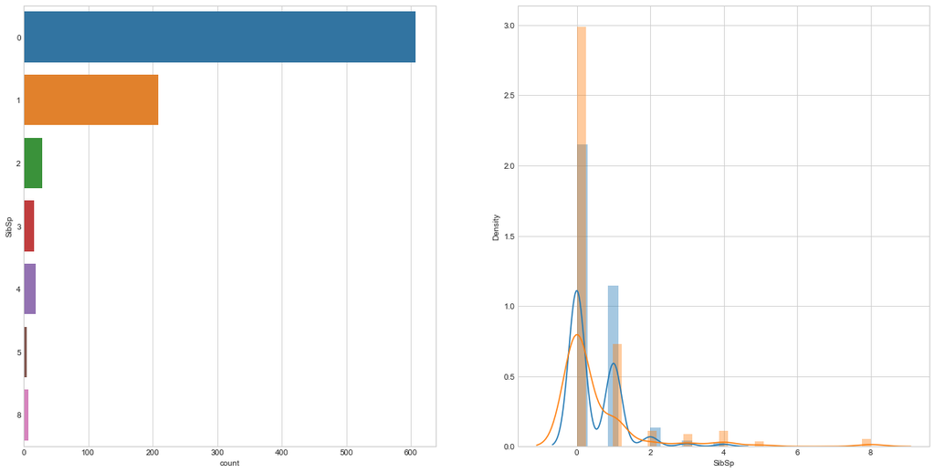

```python
# Visualise the counts of SibSp and the distribution of the values
# against Survived
plot_count_dist(train_df,
                label_column='Survived',
                target_column='SibSp',
                figsize=(20, 10))
```

## 1.3.7 Feature: Parch

Description: The number of parents/children the passenger has aboard the Titanic.

**How many missing values does Parch have?**

```python
train_df.Parch.isnull().sum()
```

```
0
```

**What values are there?**

```python
train_df.Parch.value_counts()
```

```
0    678
1    118
2     80
5      5
3      5
4      4
6      1
Name: Parch, dtype: int64
```

```python
# Add Parch to subset dataframes
df['Parch'] = train_df['Parch']
df.head()
```

|  | Survived | Pclass | Sex | Age | SibSp | Parch |
| --- | --- | --- | --- | --- | --- | --- |
| 0 | 0 | 3 | 0 | 22.0 | 1 | 0 |
| 1 | 1 | 1 | 1 | 38.0 | 1 | 0 |
| 2 | 1 | 3 | 1 | 26.0 | 0 | 0 |
| 3 | 1 | 1 | 1 | 35.0 | 1 | 0 |
| 4 | 0 | 3 | 0 | 35.0 | 0 | 0 |

**Visualise the counts of Parch and the distribution of the values VS. Survived**

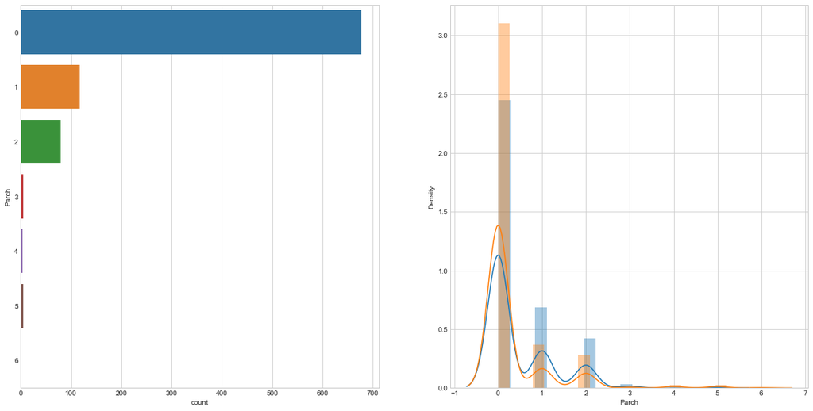

```python
plot_count_dist(train_df,
                label_column='Survived',
                target_column='Parch',
                figsize=(20, 10))
```

### 1.3.8 Feature: Ticket

Description: The ticket number of the boarding passenger.

**How many missing values does Ticket have?**

```python
train_df.Ticket.isnull().sum()
```

```
0
```

**How many kinds of ticket are there?**

```python
train_df.Ticket.value_counts()
```

```
1601                 7
CA. 2343             7
347082               7
347088               6
3101295              6
                    ..
372622               1
STON/O 2. 3101289    1
SC/AH 29037          1
347068               1
394140               1
Name: Ticket, Length: 681, dtype: int64
```

**How many unique kinds of Ticket are there?**

```python
print("There are {} unique Ticket values.".format(len(train_df.Ticket.unique())))
```

```
There are 681 unique Ticket values.
```

681 unique values is too many for now. **So we won't use `Ticket`** in our subset dataframes.

## 1.3.9 Feature: Fare

Description: How much the ticket cost.

**How many missing values does Fare have?**

```python
train_df.Fare.isnull().sum()
```

```
0
```

**How many different values of Fare are there?**

```python
train_df.Fare.value_counts()
```

```
8.0500     43
13.0000    42
7.8958     38
7.7500     34
26.0000    31
           ..
8.4583      1
9.8375      1
8.3625      1
14.1083     1
17.4000     1
Name: Fare, Length: 248, dtype: int64
```

**How many unique kinds of Fare are there?**

```python
print("There are {} unique Fare values.".format(len(train_df.Fare.unique())))
```

```
There are 248 unique Fare values.
```

Because Fare is a float (number) let's add it as it is to our sub dataframe

```python
# Add Fare to sub dataframes
df['Fare'] = train_df['Fare']
df.head()
```

|  | Survived | Pclass | Sex | Age | SibSp | Parch | Fare |
| --- | --- | --- | --- | --- | --- | --- | --- |
| 0 | 0 | 3 | 0 | 22.0 | 1 | 0 | 7.2500 |
| 1 | 1 | 1 | 1 | 38.0 | 1 | 0 | 71.2833 |
| 2 | 1 | 3 | 1 | 26.0 | 0 | 0 | 7.9250 |
| 3 | 1 | 1 | 1 | 35.0 | 1 | 0 | 53.1000 |
| 4 | 0 | 3 | 0 | 35.0 | 0 | 0 | 8.0500 |

**Visualise the Fare bin counts as well as the Fare distribution versus Survived.**

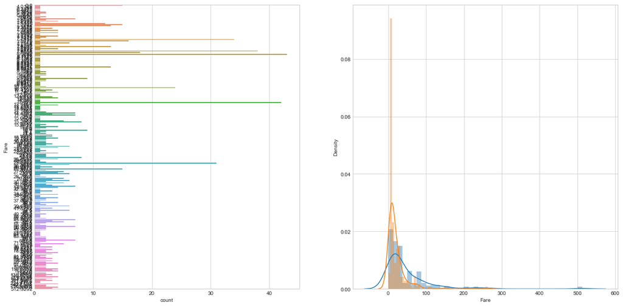

```python
plot_count_dist(data=train_df,
                label_column='Survived',
                target_column='Fare',
                figsize=(20,10))
```

## 1.3.10 Feature: Cabin

Description: The cabin number where the passenger was staying.

**How many missing values does Cabin have?**

```python
train_df.Cabin.isnull().sum()
```

```
687
```

**What do the Cabin values look like?**

```python
train_df.Cabin.value_counts()
```

```
C23 C25 C27    4
G6             4
B96 B98        4
C22 C26        3
E101           3
              ..
C30            1
B86            1
E10            1
D37            1
F G63          1
Name: Cabin, Length: 147, dtype: int64
```

Since there are too many missing values, we **won't use Cabin** for our models and won't add it to our sub dataframes.

### 1.3.11 Feature: Embarked

Description: The port where the passenger boarded the Titanic.

Key: `C = Cherbourg`, `Q = Queenstown`, `S = Southampton`

**How many missing values does Embarked have?**

```python
train_df.Embarked.isnull().sum()
```

```
2
```

**What kind of values are in Embarked?**

```python
train_df.Embarked.value_counts()
```

```
S    644
C    168
Q     77
Name: Embarked, dtype: int64
```

Embarked is a categorical variable because there are 3 categories which a passenger could have boarded on.

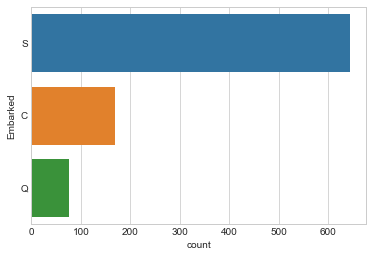

```python
sns.countplot(y='Embarked', data=train_df)
```

**Dealing with the two missing values of Embarked**

```python
# Add Embarked to sub dataframes
df['Embarked'] = train_df['Embarked']
df.head()
```

|  | Survived | Pclass | Sex | Age | SibSp | Parch | Fare | Embarked |
| --- | --- | --- | --- | --- | --- | --- | --- | --- |
| 0 | 0 | 3 | 0 | 22.0 | 1 | 0 | 7.2500 | S |
| 1 | 1 | 1 | 1 | 38.0 | 1 | 0 | 71.2833 | C |
| 2 | 1 | 3 | 1 | 26.0 | 0 | 0 | 7.9250 | S |
| 3 | 1 | 1 | 1 | 35.0 | 1 | 0 | 53.1000 | S |
| 4 | 0 | 3 | 0 | 35.0 | 0 | 0 | 8.0500 | S |

```python
# Remove Embarked rows which are missing values
print(len(df))
df = df.dropna(subset=['Embarked'])
df = df.dropna(subset=['Embarked'])
print(len(df))
```

```
891
889
```

```python
df.head(10)
```

|  | Survived | Pclass | Sex | Age | SibSp | Parch | Fare | Embarked |
| --- | --- | --- | --- | --- | --- | --- | --- | --- |
| 0 | 0 | 3 | 0 | 22.000000 | 1 | 0 | 7.2500 | S |
| 1 | 1 | 1 | 1 | 38.000000 | 1 | 0 | 71.2833 | C |
| 2 | 1 | 3 | 1 | 26.000000 | 0 | 0 | 7.9250 | S |
| 3 | 1 | 1 | 1 | 35.000000 | 1 | 0 | 53.1000 | S |
| 4 | 0 | 3 | 0 | 35.000000 | 0 | 0 | 8.0500 | S |
| 5 | 0 | 3 | 0 | 29.699118 | 0 | 0 | 8.4583 | Q |
| 6 | 0 | 1 | 0 | 54.000000 | 0 | 0 | 51.8625 | S |
| 7 | 0 | 3 | 0 | 2.000000 | 3 | 1 | 21.0750 | S |
| 8 | 1 | 3 | 1 | 27.000000 | 0 | 2 | 11.1333 | S |
| 9 | 1 | 2 | 1 | 14.000000 | 1 | 0 | 30.0708 | C |

# 2. Feature Encoding

```python
# One hot encode the categorical columns
df_embarked_one_hot = pd.get_dummies(df['Embarked'],
                                     prefix='embarked')

df_sex_one_hot = pd.get_dummies(df['Sex'],
                                prefix='sex')

df_plcass_one_hot = pd.get_dummies(df['Pclass'],
                                   prefix='pclass')
```

```python
# Combine the one hot encoded columns with df_con_enc
df_enc = pd.concat([df,
                        df_embarked_one_hot,
                        df_sex_one_hot,
                        df_plcass_one_hot], axis=1)

# Drop the original categorical columns (because now they've been one hot encoded)
df_enc = df_enc.drop(['Pclass', 'Sex', 'Embarked'], axis=1)

# Let's look at df_enc
df_enc.head(20)
```

|  | Survived | Age | SibSp | Parch | Fare | embarked_C | embarked_Q | embarked_S | sex_0 | sex_1 | pclass_1 | pclass_2 | pclass_3 |
| --- | --- | --- | --- | --- | --- | --- | --- | --- | --- | --- | --- | --- | --- |
| 0 | 0 | 22.000000 | 1 | 0 | 7.2500 | 0 | 0 | 1 | 1 | 0 | 0 | 0 | 1 |
| 1 | 1 | 38.000000 | 1 | 0 | 71.2833 | 1 | 0 | 0 | 0 | 1 | 1 | 0 | 0 |
| 2 | 1 | 26.000000 | 0 | 0 | 7.9250 | 0 | 0 | 1 | 0 | 1 | 0 | 0 | 1 |
| 3 | 1 | 35.000000 | 1 | 0 | 53.1000 | 0 | 0 | 1 | 0 | 1 | 1 | 0 | 0 |
| 4 | 0 | 35.000000 | 0 | 0 | 8.0500 | 0 | 0 | 1 | 1 | 0 | 0 | 0 | 1 |
| 5 | 0 | 29.699118 | 0 | 0 | 8.4583 | 0 | 1 | 0 | 1 | 0 | 0 | 0 | 1 |
| 6 | 0 | 54.000000 | 0 | 0 | 51.8625 | 0 | 0 | 1 | 1 | 0 | 1 | 0 | 0 |
| 7 | 0 | 2.000000 | 3 | 1 | 21.0750 | 0 | 0 | 1 | 1 | 0 | 0 | 0 | 1 |
| 8 | 1 | 27.000000 | 0 | 2 | 11.1333 | 0 | 0 | 1 | 0 | 1 | 0 | 0 | 1 |
| 9 | 1 | 14.000000 | 1 | 0 | 30.0708 | 1 | 0 | 0 | 0 | 1 | 0 | 1 | 0 |
| 10 | 1 | 4.000000 | 1 | 1 | 16.7000 | 0 | 0 | 1 | 0 | 1 | 0 | 0 | 1 |
| 11 | 1 | 58.000000 | 0 | 0 | 26.5500 | 0 | 0 | 1 | 0 | 1 | 1 | 0 | 0 |
| 12 | 0 | 20.000000 | 0 | 0 | 8.0500 | 0 | 0 | 1 | 1 | 0 | 0 | 0 | 1 |
| 13 | 0 | 39.000000 | 1 | 5 | 31.2750 | 0 | 0 | 1 | 1 | 0 | 0 | 0 | 1 |
| 14 | 0 | 14.000000 | 0 | 0 | 7.8542 | 0 | 0 | 1 | 0 | 1 | 0 | 0 | 1 |
| 15 | 1 | 55.000000 | 0 | 0 | 16.0000 | 0 | 0 | 1 | 0 | 1 | 0 | 1 | 0 |
| 16 | 0 | 2.000000 | 4 | 1 | 29.1250 | 0 | 1 | 0 | 1 | 0 | 0 | 0 | 1 |
| 17 | 1 | 29.699118 | 0 | 0 | 13.0000 | 0 | 0 | 1 | 1 | 0 | 0 | 1 | 0 |
| 18 | 0 | 31.000000 | 1 | 0 | 18.0000 | 0 | 0 | 1 | 0 | 1 | 0 | 0 | 1 |
| 19 | 1 | 29.699118 | 0 | 0 | 7.2250 | 1 | 0 | 0 | 0 | 1 | 0 | 0 | 1 |

# 3. Start Building Machine Learning Models

Now our data has been manipulating and converted to numbers, we can run a series of different machine learning algorithms over it to find which yield the best results.

## 3.1 Seperate the data

```python
# Seclect the dataframe we want to use first for predictions
selected_df = df_enc
```

```python
selected_df.head()
```

|  | Survived | Age | SibSp | Parch | Fare | embarked_C | embarked_Q | embarked_S | sex_0 | sex_1 | pclass_1 | pclass_2 | pclass_3 |
| --- | --- | --- | --- | --- | --- | --- | --- | --- | --- | --- | --- | --- | --- |
| 0 | 0 | 22.0 | 1 | 0 | 7.2500 | 0 | 0 | 1 | 1 | 0 | 0 | 0 | 1 |
| 1 | 1 | 38.0 | 1 | 0 | 71.2833 | 1 | 0 | 0 | 0 | 1 | 1 | 0 | 0 |
| 2 | 1 | 26.0 | 0 | 0 | 7.9250 | 0 | 0 | 1 | 0 | 1 | 0 | 0 | 1 |
| 3 | 1 | 35.0 | 1 | 0 | 53.1000 | 0 | 0 | 1 | 0 | 1 | 1 | 0 | 0 |
| 4 | 0 | 35.0 | 0 | 0 | 8.0500 | 0 | 0 | 1 | 1 | 0 | 0 | 0 | 1 |

```python
from sklearn.model_selection import train_test_split

X = selected_df.drop('Survived', axis=1)
y = selected_df.Survived

X_train, X_test, y_train, y_test = train_test_split(X, y, test_size=0.3, random_state=42)
```

```python
print(X_train.shape)
print(X_test.shape)
print(y_train.shape)
print(y_test.shape)
```

```
(622, 12)
(267, 12)
(622,)
(267,)
```

```python
X_train.head()
```

|  | Age | SibSp | Parch | Fare | embarked_C | embarked_Q | embarked_S | sex_0 | sex_1 | pclass_1 | pclass_2 | pclass_3 |
| --- | --- | --- | --- | --- | --- | --- | --- | --- | --- | --- | --- | --- |
| 486 | 35.0 | 1 | 0 | 90.0000 | 0 | 0 | 1 | 0 | 1 | 1 | 0 | 0 |
| 293 | 24.0 | 0 | 0 | 8.8500 | 0 | 0 | 1 | 0 | 1 | 0 | 0 | 1 |
| 173 | 21.0 | 0 | 0 | 7.9250 | 0 | 0 | 1 | 1 | 0 | 0 | 0 | 1 |
| 450 | 36.0 | 1 | 2 | 27.7500 | 0 | 0 | 1 | 1 | 0 | 0 | 1 | 0 |
| 361 | 29.0 | 1 | 0 | 27.7208 | 1 | 0 | 0 | 1 | 0 | 0 | 1 | 0 |

```python
y_train.head()
```

```
486    1
293    0
173    0
450    0
361    0
Name: Survived, dtype: int64
```

```python
X_test.head()
```

|  | Age | SibSp | Parch | Fare | embarked_C | embarked_Q | embarked_S | sex_0 | sex_1 | pclass_1 | pclass_2 | pclass_3 |
| --- | --- | --- | --- | --- | --- | --- | --- | --- | --- | --- | --- | --- |
| 281 | 28.0 | 0 | 0 | 7.8542 | 0 | 0 | 1 | 1 | 0 | 0 | 0 | 1 |
| 435 | 14.0 | 1 | 2 | 120.0000 | 0 | 0 | 1 | 0 | 1 | 1 | 0 | 0 |
| 39 | 14.0 | 1 | 0 | 11.2417 | 1 | 0 | 0 | 0 | 1 | 0 | 0 | 1 |
| 418 | 30.0 | 0 | 0 | 13.0000 | 0 | 0 | 1 | 1 | 0 | 0 | 1 | 0 |
| 585 | 18.0 | 0 | 2 | 79.6500 | 0 | 0 | 1 | 0 | 1 | 1 | 0 | 0 |

```python
y_test.head()
```

```
281    0
435    1
39     1
418    0
585    1
Name: Survived, dtype: int64
```

## 3.2 Applying machine learning algorithms

### 3.2.1 Decision Tree Classifier

```python
tree_clf = DecisionTreeClassifier(random_state=42)
tree_clf.fit(X_train, y_train)
pred = tree_clf.predict(X_test)

print("Accuracy Score: ", accuracy_score(y_test, pred) * 100)
print("Classification Report: \n", classification_report(y_test, pred))
```

```
Accuracy Score:  76.77902621722846
Classification Report:
               precision    recall  f1-score   support

           0       0.83      0.79      0.81       167
           1       0.68      0.73      0.70       100

    accuracy                           0.77       267
   macro avg       0.75      0.76      0.76       267
weighted avg       0.77      0.77      0.77       267
```

### 3.2.2 K-nearest neighbors

```python
knn_clf = KNeighborsClassifier()
knn_clf.fit(X_train, y_train)
pred = knn_clf.predict(X_test)

print("Accuracy Score: ", accuracy_score(y_test, pred) * 100)
print("Classification Report: \n", classification_report(y_test, pred))
```

```
Accuracy Score:  70.78651685393258
Classification Report:
               precision    recall  f1-score   support

           0       0.74      0.82      0.78       167
           1       0.63      0.52      0.57       100

    accuracy                           0.71       267
   macro avg       0.69      0.67      0.67       267
weighted avg       0.70      0.71      0.70       267
```

### 3.2.3 Gaussian Naive Bayes

```python
clf = GaussianNB()
clf.fit(X_train, y_train)
pred = clf.predict(X_test)

print("Accuracy Score: ", accuracy_score(y_test, pred) * 100)
print("Classification Report: \n", classification_report(y_test, pred))
```

```
Accuracy Score:  77.90262172284645
Classification Report:
               precision    recall  f1-score   support

           0       0.84      0.80      0.82       167
           1       0.69      0.74      0.71       100

    accuracy                           0.78       267
   macro avg       0.76      0.77      0.77       267
weighted avg       0.78      0.78      0.78       267
```